# Ethiopia Baseline Risk Analysis

Analysis last updated 06-10-2021.

This document is an initial exploration into risk of humanitarian need in Ethiopia. We’re focusing most closely on climate-related risks, such as floods and drought. This document presents the outputs of basic data collection and analysis. It is intended to provide a starting point for a more in depth risk analysis for Ethiopia’s upcoming Humanitarian Needs Overview.

## Historical Analysis

Relevant datasets include:

1. [Global Flood Database](http://global-flood-database.cloudtostreet.info/#interactive-map)
- Gridded data of historical flood extents available via [Google Earth Engine](https://developers.google.com/earth-engine/datasets/catalog/GLOBAL_FLOOD_DB_MODIS_EVENTS_V1).
- Includes flood events from 2000-2018. Ethiopia has 28 events recorded.
- Events identified from the Dartmouth Flood Observatory, with flood extent mapped using MODIS satellite imagery.
2. [EM-DAT](https://www.emdat.be/database)
- Historical catalogue of both flood and drought events from 1965-2021.
- Dataset includes 74 events.
- Geolocated somewhat inconsistently to most often the Admin 1 or 2 level.

The figure below shows the national count of shock events per year, as recorded in EM-DAT.

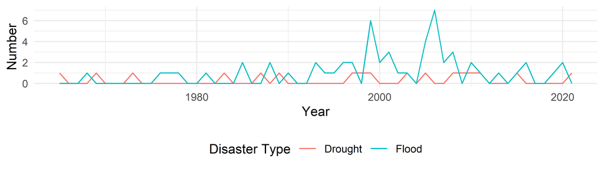

National count of shock events per year

The figure below shows the frquency of floods (left) and drought (right) by region since 1965. NOTE that the geolocation of events in these figures still needs to be fully validated.

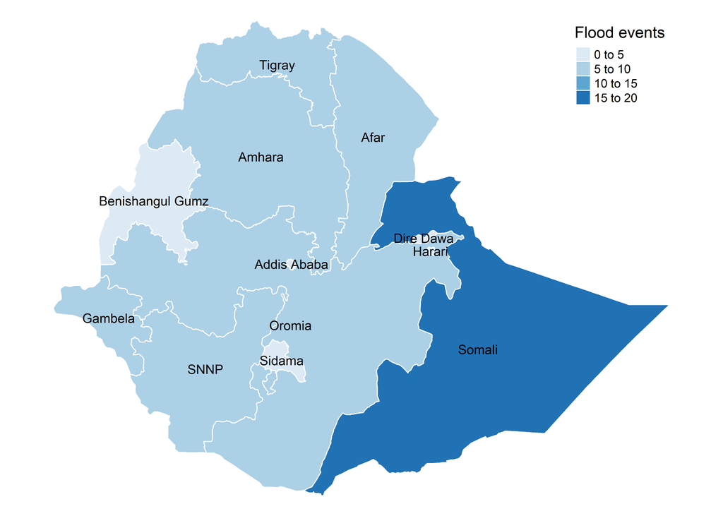

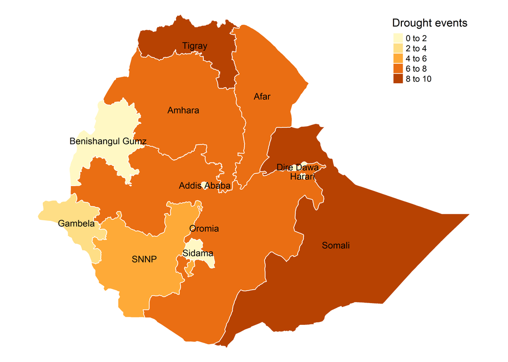

Historical frequency of shock events by Region

The tables below show the full lists of both the flood and drought events from EM-DAT.

List of flood events

| Year | Location | Origin | Total Affected |
| --- | --- | --- | --- |
| 1968 | Kelafo | NA | 16000 |
| 1976 | Gode, Kelafo, Mustahil | NA | 70000 |
| 1977 | Awash River Valley | NA | 16000 |
| 1978 | NA | NA | 1000 |
| 1981 | Kalafo | NA | 20000 |
| 1985 | Rift Valley region | NA | 8000 |
|  | Ogaden | NA | 20000 |
| 1988 | Gambella | NA | 45000 |
|  | Sidamo province, /Dollo | NA | 2240 |
| 1990 | Gambela region | Heavy rain | 350000 |
| 1993 | Near Addis Abeba | NA | 4800 |
|  | Gollam, Gonder regions | NA | 30000 |
| 1994 | North Shoa, South Welo, Tach Gayint district (Gonder province) | Heavy rain | 43014 |
| 1995 | Kelafo, Mustahil, Ferfer, Burukur (Eastern Ogaden region) | Heavy rain | 93875 |
| 1996 | Gambella Region | NA | 90000 |
|  | Gambella region, East-Shoa, Wanji provinces | Heavy rains | 25000 |
| 1997 | Afder and Liben districts (Somali region), Gode, Haregele, Dollo regions | Heavy rain | 65000 |
|  | Arba Minch region | Heavy rain | 22 |
| 1999 | Mustahil, Kefalo (Ogaden region of South-East Ethiopia) | Brief torrential rain | 79000 |
|  | Iowlands | Heavy rain | 6755 |
|  | Sud Tigré (Nord) | NA | 500 |
|  | Zone D’assosa (Region Du Beninshangul-Gumuz) | NA | NA |
|  | Limu District (South Of Ethiopia) | NA | 45000 |
|  | Itang District | NA | 16000 |
| 2000 | Dubti area (Zone 1 district, Afar province) | Heavy rain | 30000 |
|  | Nazareth city (East Shewa district, Oromia province), Region 14 district (Addis Ababa province) | NA | NA |
| 2001 | Dubti, Asaita areas (Zone 1 district, Afar province) | NA | 31000 |
|  | Gambela province | NA | 6000 |
|  | Himora town (Western district, Tigray province) | NA | 2500 |
| 2002 | Afar, Oromia, Somali region | Heavy rain | 4000 |
| 2003 | Somali province | Hevay rains | 110000 |
| 2005 | Dire Dawa, Somali provinces | Heavy rains | 235418 |
|  | Tigray, Oromia, Amhara provinces | Heavy rains | NA |
|  | Dire Dawa province | NA | NA |
|  | Oromia province | Heavy rains | 7000 |
| 2006 | Dire Dawa district (Dire Dawa province), Addis Ketema, Genfele, Coca Cola, Aftessa boroughs (Region 14 district, Addis Ababa province) | Heavy Rain | 10096 |
|  | Afar, Somali provinces | Heavy rain | 10000 |
|  | Tigray province | NA | 450 |
|  | Omorate, Gangato villages (South Omo district, SNNPR province) | Heavy rain | 8000 |
|  | Amhara, Gambela, Afar provinces | Heavy rain | 38000 |
|  | Gambela province | NA | 6000 |
|  | Gode, Kelafo, Mustahil, East Imi, Ferfer, Denan towns (Shabelle district, Somali province), Kebri Dehar town (Korahe district, Somali province) | Heavy rain | 361600 |
| 2007 | South Omo district (SNNPR province) | Heavy rain | 5800 |
|  | Gambela, Amhara, SNNPR, Addis Ababa, Afar, Tigray, Somali provinces | Heavy rain | 239586 |
| 2008 | Gambela province | Heavy seasonal rains | 91764 |
|  | Jijiga town (Fafan district, Somali province) | Heavy rains | 845 |
|  | West Imi town (Afder district, Somali province), Dolo town (Doolo district, Somali province), Kebri Beyah town (Fafan district, Somali province), Halaba area (Selti district, SNNPR province), Kachabir… | Heavy rains | 23831 |
| 2010 | Mustahil, Kelafo villages (Shabelle district, Somali province) | Heavy rains | 55700 |
|  | Afar, Amhara, Tigray provinces | Heavy rains | 25000 |
| 2011 | Mustahil, Kelafo villages (Shabelle district, Somali province) | NA | 40200 |
| 2013 | Korahe, Jarar, Shabelle districts (Somali province), Wolayita, Sidama districts (SNNPR province) | NA | 51500 |
| 2015 | Shabelle district (Somali province) | NA | 210600 |
| 2016 | Jijiga city (Fafan district, Somali province), Wolayita district (SNNPR province), Afar, Amhara, Tigray, Oromia provinces | Torrential rains, El Nino | 3080 |
|  | Wolayita district (SNNPR province), Bale district (Oromia province) | Torrential rains | 490000 |
| 2019 | Somali region | NA | 200000 |
| 2020 | Dire Dawa City, SNNPR | NA | 219000 |
|  | South Gondar zone (Amhara Region); Afar, Gambella, Oromia, Somali, SNNPR | Heavy rains | 1010854 |

List of drought events

| Year | Location | Origin | Total Affected |
| --- | --- | --- | --- |
| 1965 | Nationwide | NA | 1500000 |
| 1969 | Hamasion division | NA | 1700000 |
| 1973 | Tigre, Wollo, North Shoa, Tigray, Kangra provinces | NA | 3000000 |
| 1983 | Wollo, Gondar, Goe, Eritrea, Tigrai, Shoa, Harerge, Sidamo | NA | 7750000 |
| 1987 | Ogaden, Eritrea, Tigray, Wello, Shewa, Gama, Gofa, Sidamo, Gondar, Bale | NA | 7000000 |
| 1989 | Northern Ethiopia, Eritrea, Tigray, Wollo, Gondar, Harerge | NA | 6500000 |
| 1997 | Borena, Bale (Oromiya state) South Ome zone, Somali state | NA | 986200 |
| 1998 | NA | NA | NA |
| 1999 | North Wollo, South Wollo, Oromia, Wag Himra districts (Amhara province), Southern district (Tigray province), Beneshangul Gumu, Gambela, Oromia, SNNPR, Somali provinces | NA | 4900000 |
| 2003 | Tigray, Oromia, Amhara, Somali, Afar provinces | Crop failure, lack pasture, poor/erratic long rains | 12600000 |
| 2005 | Afder, Liben districts (Somali province), Gode zones (Shabelle district, Somali province), Borena district (Oromiya province) | Successive failed rainy seasons | 2600000 |
| 2008 | Oromia, Somali, Amhara, Afar, Tigray, SNNPR provinces | Heavy drought, weak reany season, loss of animals, food shortages and increase of prices | 6400000 |
| 2009 | Somali, Oromia, Afar, Tigray, Amhara, SNNP, Gambela provinces | Poor rainfall | 6200000 |
| 2010 | Somali, Oromia, Afar, Tigray, Amhara provinces | La Nina | 4805679 |
| 2011 | Dire Dawa, Gambela, Hareri, Oromia, SNNPR, Somali, Addis Ababa provinces (Southern Ethiopia) | Consecutive seasons of poor rainfall, rapid population growth, sustained high food prices, endemic poverty | 1000000 |
| 2015 | Somali, Afar, Oromia, Amhara, Nations du Sud provinces | El Nino | 10200000 |
| 2021 | Tigray, Afar and Amhara | NA | 5500000 |

3. [IDMC](https://data.humdata.org/dataset/idmc-idp-data-for-ethiopia)
- Number of IDPs, relating to conflict and disaster.
- Not subnational.
- Data available between 2008-2020.
4. [IOM DTM Site Assessment](https://data.humdata.org/dataset/ethiopia-baseline-assessment-data-iom-dtm)
- Assessment late Dec 2020, early Jan 2021.
- At Admin 3 level.
- For each site, includes reason for displacement and breakdown of population by age and gender.
5. [FAOSTAT Food Security Indicators](https://data.humdata.org/dataset/faostat-food-security-indicators-for-ethiopia)
- National level indicators from 2000-2020
- Such as: Prevalence of undernourishment (percent) (3-year average), Number of severely food insecure people (million) (3-year average), Percentage of population using safely managed sanitation services (Percent)

## Near-present situation

1. [Standardized Precipitation Index](https://code.earthengine.google.com/5d3600853925e070e57c9f733072e274)
- Researched in past MapAction work in Ethiopia:

> Standardized Precipitation Index (SPI) is the most commonly used indicator worldwide for detecting and characterizing meteorological droughts. It measures precipitation anomalies at a given location based on a comparison of observed total precipitation amounts for an accumulation period of interest (e.g. 3, 6, 9 months), with the long-term historic rainfall record for that period. Rainfall deficits (i.e. meteorological droughts) are indicated as SPI decreases below -1.0, while excess rainfall are indicated as SPI increases above 1.0. As SPI values are in units of standard deviation from the long-term mean, the indicator can be used to compare precipitation anomalies for any geographic location and for any number of time scales. The World Meteorological Organization has recommended that the SPI be used by all National Meteorological and Hydrological Services around the world to characterize meteorological droughts